**DSE 220: Machine Learning Final Exam/Project**

*Arlens Zeqollari*

# Setup and Instructions

## **1 - Instructions**

The deadline for the kaggle competition is 9 June 2019 (11:59 PM PST). The report and the code for the final should be submitted on Gradescope by 9 June 2019 (11:59 PM PST). To secure full marks both the report and the code should be in sync and logically correct. Please only submit relevant and legible code. Please complete the final individually.

## **2 - Overview**

For the take-home final of DSE 220: Machine Learning, we combine all the concepts we have learned so far and apply them to a real world problem. The problem, in very broad terms, is to predict how useful an Amazon product review is going to be. The problem is open-ended and you can use any method you like.

Amazon is a leading e-commerce website and uses Machine Learning appli- cations extensively in their products. For example, they recommend products based on your browsing history and previous purchases so as to maximize their profit (by selling you another product!). For your final, you are given Amazon data. Given a review, the item for which the review is and the user who has written the review, you need to predict how helpful the review will be.

Solutions will be graded on Kaggle. Please follow the link - https://www.kaggle.com/t/7d53b23e032a4edfb0364499ae07cbda

to view the webpage and signup using your UCSD email id (@ucsd.edu and not @eng.ucsd.edu). Note that the time reported on Kaggle are in UTC and not PST.

You will also be graded on a brief report, to be submitted electronically on Gradescope. Your grades will be determined by your performance on the pre- dictive task as well as your written report about the approaches you took.

## 3 - Files

**train.json.gz** - 200,000 reviews to be used for training. It is not necessary to use all reviews for training, for example if doing so proves too computationally intensive. While these files are one-json-per-line, you may find it useful to represent them more concisely in order to produce a more efficient solution.

> The fields in this file are:
> - **itemID** The ID of the item. This is a hashed product identifier from Amazon.
> - **reviewerID** The ID of the reviewer. This is a hashed user identifier from Amazon.
> - **helpful** Helpfulness votes for the review. This has two subfields, ‘nHelpful’ and ‘outOf’. The latter is the total number of votes this review received, the former is the number of those that considered the review to be helpful.
> - **reviewText** The text of the review. It should be possible to successfully complete this task without making use of the review data, though an effective solution to the helpfulness prediction task will presumably make use of it.
> - **summary** Summary of the review.
> - **price** Price of the item.
> - **reviewHash** Hash of the review (essentially a unique identifier for the review).
> - **unixReviewTime** Time of the review, i.e, time elapsed in seconds since 1970. For example - 1400544000
> - **reviewTime** Plain-text representation of the review time in human read- able format. For example - ’05 20, 2014’
> - **category** Category labels of the product being reviewed.
> - **rating** Rating given by the reviewer.

**pairs_Helpful.txt** Pairs on which you are to predict helpfulness votes. A third column in this file is the total number of votes, from which you should predict how many were helpful.

**test_Category.json.gz** The review data associated with the category prediction test set. Again, the field that you are trying to predict has been removed.

**Baseline.ipynb** A simple baseline for the task, described later.

## 4 - Task

**Helpfulness prediction** - Predict whether a user’s review of an item will be considered helpful. The file ’pairs Helpful.txt’ contains (user,item) pairs, with a third column containing the number of votes the user’s review of the item received. You must predict how many of them were helpful. Accuracy will be measured in terms of the mean absolute error, i.e., you are penalized one according to the **absolute difference of nHelpful and prediction**, where ’nHelpful’ is the number of helpful votes the review actually received, and ’prediction’ is your prediction of this quantity.

The error measure is described on Kaggle: Mean Absolute error

A competition page has been set up on Kaggle to keep track of your results compared to those of other members of the class. The leaderboard will show your results on half of the test data, but your ultimate score will depend on your predictions across the whole dataset.

## 5 - Grading and Evaluation

You will be graded on the following aspects.

- Your ability to obtain a solution which outperforms the baselines on the total test data (including the unseen portion). Obtaining full marks requires a solution which is substantially better than baseline performance.

> Following are the marks you’ll get for beating every benchmark.

> > Baseline: 0.261

> > Benchmark I: ≤ 0.190 15 marks

> > Benchmark II: ≤ 0.185 20 marks

> > Benchmark III: ≤ 0.179 25 marks

> > Benchmark IV: ≤ 0.176 30 marks

> > Benchmark V: ≤ 0.173 35 marks

> > Benchmark VI: ≤ 0.170 40 marks

> > Benchmark VII: ≤ 0.166 45 marks

> > Benchmark VIII: ≤ 0.162 50 marks
- Obtain a solution which outperforms the baselines on the seen portion of the test data (i.e., the public leaderboard) to obtain 20 marks. This is a consolation prize in case you overfit to the leaderboard.
- The report accounts for 30 marks. It should describe the approaches you took to perform the task. Make sure that the methods you describe in the report include all the aspects of your final model including pre-processing, feature engineering etc. The aim is that anyone with your report should be able to recreate your results. Even if your model doesn’t perform well, you can obtain marks in this section for the comprehensiveness of your analysis.

You can obtain a maximum of 100 marks in this project, which will the scaled down to 40% of the total course assessment. To obtain good performance, you should not need to invent new approaches (though you are more than welcome to!).

## 6 - Kaggle

We have set up a Kaggle page to help you evaluate your solution. You should be able to access the competition via your UCSD address(@ucsd.edu, not @eng.ucsd.edu).

https://www.kaggle.com/t/7d53b23e032a4edfb0364499ae07cbda

You can submit only 20 submissions per day to Kaggle. This is to ensure that you don’t learn from the test data. Please ensure that you use a good validation set for measuring the performance of your model. Tuning your models based on the leaderboard position can lead to overfitting and you might end up losing all the marks based on the private leaderboard.

You need to select two top submissions on which you want us to evaluate you at the end of the competition. If top two submissions are not selected, we pick the top two submissions according to the public leaderboard.

## 7 - Baselines

Simple baseline solution has been provided for the task. These are included in ‘Baseline.ipynb’ among the files above. The baseline operate as follows:

Multiply the number of votes by the global average helpfulness ratio (nHelpful/outOf), or the user’s average helpfulness ratio if we saw the same user in the training data.

Running the given iPython notebook produces files containing predicted outputs. Your submission files should have the same format. Hints will be provided to you on Piazza by the TAs from time to time depending upon the class per- formance. Please monitor Piazza posts for updates.

# Import Required Libraries

```python
import numpy as np
import pandas as pd
import seaborn as sns
from matplotlib import pyplot as plt

import json
import gzip
from collections import defaultdict

from sklearn.preprocessing import MultiLabelBinarizer
import nltk
from nltk import word_tokenize, pos_tag

from sklearn.model_selection import train_test_split
from sklearn.linear_model import LinearRegression
from sklearn.tree import DecisionTreeRegressor
from sklearn.ensemble import AdaBoostRegressor
from sklearn import metrics
from textblob import TextBlob

nltk.download('averaged_perceptron_tagger');
nltk.download('punkt');
nltk.download('wordnet')
```

```
True
```

## Helpfulness Baseline

### Compute the global average helpfulness rate, and the average helpfulness rate for each user

```python
def readGz(f):
  for l in gzip.open(f):
    yield eval(l)

allHelpful = []
userHelpful = defaultdict(list)
itemHelpful = defaultdict(list)

for l in readGz("train.json.gz"):
  user,item = l['reviewerID'],l['itemID']
  allHelpful.append(l['helpful'])
  userHelpful[user].append(l['helpful'])
  itemHelpful[item].append(l['helpful'])

averageRate = sum([x['nHelpful'] for x in allHelpful]) * 1.0 / sum([x['outOf'] for x in allHelpful])
userRate = {}
for u in userHelpful:
  totalU = sum([x['outOf'] for x in userHelpful[u]])
  if totalU > 0:
    userRate[u] = sum([x['nHelpful'] for x in userHelpful[u]]) * 1.0 / totalU
  else:
    userRate[u] = averageRate

itemRate = {}
for i in itemHelpful:
  totalI = sum([x['outOf'] for x in itemHelpful[i]])
  if totalI > 0:
    itemRate[i] = sum([x['nHelpful'] for x in itemHelpful[i]]) * 1.0 / totalI
  else:
    itemRate[i] = averageRate
```

```python
# Average Global Helpfulness rate
print('Average Global Helpfulness Rate',averageRate)
```

```
Average Global Helpfulness Rate 0.8519720886532813
```

## For reading the files in a pandas DataFrame

```python
from collections import defaultdict

def readGz(f):
    for l in gzip.open(f):
        yield eval(l)

def parse(path):
    g = gzip.open(path, 'rb')
    for l in g:
        yield eval(l)

def getDF(path):
    i = 0
    df = {}
    for d in parse(path):
        df[i] = d
        i += 1
    return pd.DataFrame.from_dict(df, orient='index')
```

```python
df = getDF('train.json.gz')
```

```python
test_df = getDF('test_Helpful.json.gz')
```

# 8 - Cleaning and Feature Generation

## Training df

```python
# Create 'outOf' from 'helpful'
df['outOf'] = df['helpful'].map(lambda x: x['outOf'])

# Create 'reviews_per_item'
reviews_per_item = dict(df.itemID.value_counts())
df['total_item_reviews'] = df['itemID'].map(lambda item: reviews_per_item[item])

# Remove all rows where outOf < 10
#df = df[df['outOf'] < 10]
df = df[df['outOf'] >= 1]

# Create 'nHelpful' from 'helpful'
df['nHelpful'] = df['helpful'].map(lambda x: list(x.values())[1]) # Will need to be removed in final submission because this is what needs to be predicted.
#df_low['nHelpful'] = df_low['helpful'].map(lambda x: list(x.values())[1])

# Create 'perc_helpful' from 'nHelpful' and 'outOf' # Will need to be removed in final submission because this is what needs to be predicted.
df['perc_helpful'] = df['nHelpful'] / df['outOf']
#df_low['perc_helpful'] = df_low['nHelpful'] / df_low['outOf']

# Sort dataset by 'nHelpful'
#df = df.sort_values('nHelpful',ascending = False) # Will need to be removed in final submission because this is what needs to be predicted.
#df = df.reset_index(drop = True) # Will need to be removed in final submission because this is what needs to be predicted.
```

```python
# Create first review time for each item - to be used for 'review_lateness' feature
first_item_review = {}
for item in df.itemID.unique():
  first_item_review[item] = min(df.unixReviewTime[df.itemID == item].to_list())
df['first_item_review'] = df.itemID.map(lambda item: first_item_review[item])
```

```python
# Create average helpfulness for reviews for each item
ave_item_helpful = {}
for item in df.itemID.unique():
  ave_item_helpful[item] = np.average(df.perc_helpful[df.itemID == item].to_list())
df['ave_item_helpful'] = df.itemID.map(lambda item: ave_item_helpful[item])
```

```python
# Create "review_len" from 'reviewText'
df['review_len'] = df['reviewText'].apply(len)

# Create 'word_count' from 'reviewText'
df['word_count'] = df['reviewText'].apply(lambda x: len(x.split()))

# Create 'ave_word_len' from 'reviewText'
df['ave_word_len'] = df['review_len'] / df['word_count']

# Create 'ave_user_helpfulness' from userRate # Can't use this if user does not exist in the training set.
df['ave_user_helpfulness'] = df.reviewerID.map(lambda x: userRate[x])

# Create User Experience Metric (num of reviews as % of total in dataset) as 'user_experience'
user_experience = dict(df.reviewerID.value_counts() / df.reviewerID.value_counts().sum())
df['user_experience'] = df.reviewerID.map(lambda x: user_experience[x])

# Create 'colon_density' from 'reviewText' since many helpful reviews detailed specific sections (example: 'Fit: ..')
df['colon_density'] = df.reviewText.map(lambda text: text.count(':')) / df['word_count']

# Generate 'numerical_density' from 'reviewText' since many helpful reviews describe dimensions and physical details of products
df['numerical_density'] = df.reviewText.apply(lambda review: sum([c.isdigit() for c in review])) / df.review_len

# Create 'exclamation_density' from 'reviewText'
df['exclamation_density'] = df.reviewText.map(lambda text: text.count('!')) / df['review_len']

# Generate density of ALL CAPS words from 'reviewText' that are greater than 2 characters (excluding words such as I, A, US, ID)
df['all_caps_density'] = df.reviewText.apply(lambda review: sum([w.isupper() for w in review.split() if len(w) > 2])) / df.word_count

# Generate 'hyphen_density' from 'reviewText'
df['hyphen_density'] = df.reviewText.map(lambda text: text.count('-')) / df['word_count']

print('50% done......')

# Generate summary word count from 'summary'
df['sum_word_count'] = df['summary'].apply(lambda x: len(x.split()))

# Create 'sum_exclamation_density' from 'summary'
df['sum_exclamation_density'] = df.summary.map(lambda text: text.count('!')) / df['sum_word_count']

# Create 'contains_update' from 'reviewText'
df['contains_update'] = df.reviewText.map(lambda text: text.lower().count('update'))

# Create 'review_lateness' from 'first_item_review'
df['review_lateness'] = df.unixReviewTime - df.first_item_review

# Convert rating to logarithm
df['log_rating'] = df.rating.map(lambda x: np.log(x))

# Fill NaN of 'price' with the mean
df['price'] = df.groupby('categoryID')['price'].transform(lambda x: x.fillna(x.mean()))

# Create 'readability' index for difficulty to read review.
import textstat

def lexicon_count(x):
    blob = TextBlob(x)
    return len({word.lemma for word, tag in blob.tags if tag[0].lower() in ["n","v","j"] and blob.words.count(word)})
df['lexicon_count'] = df.reviewText.apply(lexicon_count)

df['readability'] = df.reviewText.map(lambda x: textstat.flesch_kincaid_grade(x))

print('75% done......')

# Create polarity
df['polarity'] = df.reviewText.map(lambda x: TextBlob(x).sentiment.polarity)

# Create Subjectivity
df['subjectivity'] = df.reviewText.map(lambda x: TextBlob(x).sentiment.subjectivity)

# Create character count
def char_count(x):
    chars = sum(len(w) for w in x)
    return chars
df['char_count'] = df.reviewText.apply(char_count)

# Create sentence count
df['sentence_count'] = df.reviewText.map(lambda x: len(TextBlob(x).sentences))
```

```
50% done......
75% done......
```

```python
# Create dummies for categoryID
category_dummies = pd.get_dummies(df.categoryID, columns = ['categoryID'],prefix = 'categoryID',drop_first=True)
df = pd.concat([df,category_dummies],axis = 1)
```

```python
df['categoryID'] = df['categoryID'].astype(str)
```

## Test df

```python
# Create 'outOf' from 'helpful'
test_df['outOf'] = test_df['helpful'].map(lambda x: x['outOf'])

# Create 'reviews_per_item'
def try_reviews_per_item(x):
  try:
    #print('found item')
    reviews = reviews_per_item[x]
    return reviews
  except:
    #print('did not find item')
    return np.mean(list(reviews_per_item.values()))
test_df['total_item_reviews'] = test_df.itemID.map(lambda item: try_reviews_per_item(item))

# Create 'first_item_review'
def try_first_time_review(x):
  try:
    #print('found item')
    time = first_item_review[x]
    return time
  except:
    #print('did not find item')
    return np.mean(list(first_item_review.values()))
test_df['first_item_review'] = test_df.itemID.map(lambda item: try_first_time_review(item))

# Create average helpfulness for reviews for each item
def try_ave_help(x):
  try:
    #print('found item')
    help = ave_item_helpful[x]
    return help
  except:
    #print('did not find item')
    return np.mean(list(ave_item_helpful.values()))
test_df['ave_item_helpful'] = test_df.itemID.map(lambda item: try_ave_help(item))

# Create "review_len" from 'reviewText'
test_df['review_len'] = test_df['reviewText'].apply(len)

# Create 'word_count' from 'reviewText'
test_df['word_count'] = test_df['reviewText'].apply(lambda x: len(x.split()))

# Create 'ave_word_len' from 'reviewText'
test_df['ave_word_len'] = test_df['review_len'] / test_df['word_count']

# Create 'ave_user_helpfulness' from userRate # Defaults to global average user rating if user does not exist in the training set.
def try_user_rate(x):
  try:
    ave_user_helpfulness = userRate[x]
    #print('found user')
    return ave_user_helpfulness
  except:
    #print('did not find user')
    return averageRate
test_df['ave_user_helpfulness'] = test_df.reviewerID.map(lambda x: try_user_rate(x))

# Create User Experience Metric (num of reviews as % of total in dataset) as 'user_experience'
def try_user_experience(x):
  try:
    #print('found user')
    user_exp = user_experience[x]
    return user_exp
  except:
    #print('did not find user')
    return np.mean(list(user_experience.values()))
test_df['user_experience'] = test_df.reviewerID.map(lambda x: try_user_experience(x))

# Create 'colon_density' from 'reviewText' since many helpful reviews detailed specific sections (example: 'Fit: ..')
test_df['colon_density'] = test_df.reviewText.map(lambda text: text.count(':')) / test_df['word_count']

# Generate 'numerical_density' from 'reviewText' since many helpful reviews describe dimensions and physical details of products
test_df['numerical_density'] = test_df.reviewText.apply(lambda review: sum([c.isdigit() for c in review])) / test_df.review_len

# Create 'exclamation_density' from 'reviewText'
test_df['exclamation_density'] = test_df.reviewText.map(lambda text: text.count('!')) / test_df['review_len']

# Generate density of ALL CAPS words from 'reviewText' that are greater than 2 characters (excluding words such as I, A, US, ID)
test_df['all_caps_density'] = test_df.reviewText.apply(lambda review: sum([w.isupper() for w in review.split() if len(w) > 2])) / test_df.word_count

# Generate 'hyphen_density' from 'reviewText'
test_df['hyphen_density'] = test_df.reviewText.map(lambda text: text.count('-')) / test_df['word_count']

# Generate summary word count from 'summary'
test_df['sum_word_count'] = test_df['summary'].apply(lambda x: len(x.split()))

# Create 'sum_exclamation_density' from 'summary'
test_df['sum_exclamation_density'] = test_df.summary.map(lambda text: text.count('!')) / test_df['sum_word_count']

# Create 'contains_update' from 'reviewText'
test_df['contains_update'] = test_df.reviewText.map(lambda text: text.lower().count('update'))

# Create 'review_lateness' from 'first_item_review'
test_df['review_lateness'] = test_df.unixReviewTime - test_df.first_item_review
def remove_neg(x):
    if x < 0:
        return 0
    else:
        return x
test_df['review_lateness'] = test_df.review_lateness.apply(remove_neg) # Removed negative because of distribution

print('50% done......')

# Convert rating to logarithm
test_df['log_rating'] = test_df.rating.map(lambda x: np.log(x))

# Fill NaN of 'price' with the mean of categoryID's price
test_df['price'] = test_df.groupby('categoryID')['price'].transform(lambda x: x.fillna(x.mean()))

# Create 'readability' index for difficulty to read review.
import textstat
test_df['lexicon_count'] = test_df.reviewText.apply(lexicon_count)
test_df['readability'] = test_df.reviewText.map(lambda x: textstat.flesch_kincaid_grade(x))

# Create polarity
test_df['polarity'] = test_df.reviewText.map(lambda x: TextBlob(x).sentiment.polarity)

print('75% done......')

# Create Subjectivity
test_df['subjectivity'] = test_df.reviewText.map(lambda x: TextBlob(x).sentiment.subjectivity)

# Create character count
def char_count(x):
    chars = sum(len(w) for w in x)
    return chars
test_df['char_count'] = test_df.reviewText.apply(char_count)

# Create sentence count
test_df['sentence_count'] = test_df.reviewText.map(lambda x: len(TextBlob(x).sentences))
```

```
50% done......
75% done......
```

```python
# Create dummies for categoryID
category_dummies = pd.get_dummies(test_df.categoryID, columns = ['categoryID'],prefix = 'categoryID',drop_first=True)
test_df = pd.concat([test_df,category_dummies],axis = 1)
```

```python
test_df['categoryID'] = test_df['categoryID'].astype(str)
```

```python
df.head(2)
```

|  | categoryID | categories | itemID | reviewerID | rating | reviewText | reviewHash | reviewTime | summary | unixReviewTime | ... | lexicon_count | readability | polarity | subjectivity | char_count | sentence_count | categoryID_1 | categoryID_2 | categoryID_3 | categoryID_4 |
| --- | --- | --- | --- | --- | --- | --- | --- | --- | --- | --- | --- | --- | --- | --- | --- | --- | --- | --- | --- | --- | --- |
| 2 | 0 | [[Clothing, Shoes & Jewelry, Wedding Party Gif... | I408260822 | U441384838 | 3.0 | it's better on a man's hand.I didn't find it v... | R345042616 | 05 13, 2014 | Good price but... | 1399939200 | ... | 16 | 5.2 | 0.466667 | 0.466667 | 144 | 2 | 0 | 0 | 0 | 0 |
| 4 | 0 | [[Clothing, Shoes & Jewelry, Women, Plus-Size,... | I919238161 | U096604734 | 5.0 | I'm quite small and the XS fits me like a regu... | R317526520 | 07 30, 2013 | Great shirt | 1375142400 | ... | 33 | 14.8 | 0.286111 | 0.564103 | 424 | 2 | 0 | 0 | 0 | 0 |

2 rows × 43 columns

```python
test_df.head(2)
```

|  | categoryID | categories | itemID | reviewerID | rating | reviewText | reviewHash | reviewTime | summary | unixReviewTime | ... | lexicon_count | readability | polarity | subjectivity | char_count | sentence_count | categoryID_1 | categoryID_2 | categoryID_3 | categoryID_4 |
| --- | --- | --- | --- | --- | --- | --- | --- | --- | --- | --- | --- | --- | --- | --- | --- | --- | --- | --- | --- | --- | --- |
| 0 | 0 | [[Sports & Outdoors, Other Sports, Dance, Clot... | I520932398 | U816789534 | 3.0 | I ordered according to the size chart but it's... | R157684793 | 07 15, 2011 | Too small | 1310688000 | ... | 13 | 5.0 | 0.168333 | 0.505000 | 147 | 2 | 0 | 0 | 0 | 0 |
| 1 | 0 | [[Sports & Outdoors, Clothing, Women, Hoodies]... | I969532331 | U987148846 | 4.0 | Super thin but really cute and not cheap-looki... | R732719858 | 07 17, 2013 | Fun hoodie | 1374019200 | ... | 15 | 10.3 | 0.216667 | 0.703333 | 144 | 2 | 0 | 0 | 0 | 0 |

2 rows × 41 columns

## Compare Train and Test

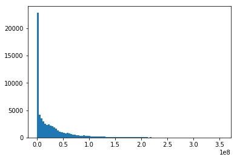

```python
plt.hist(df.review_lateness,bins=100);
```

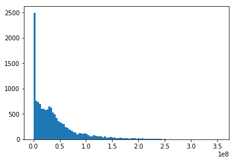

```python
plt.hist(test_df.review_lateness,bins=100);
```

## Generate Noun Density

```python
# takes approximately 10 minutes to run
nltk.download('averaged_perceptron_tagger');
nltk.download('punkt');
def count_nouns(review):
  num_nouns = sum(1 for word, pos, in pos_tag(word_tokenize(review)) if pos == 'NN')
  return num_nouns

noun_count = df.reviewText.map(lambda x: count_nouns(x))
```

```python
# Generate noun density
df['noun_density'] = noun_count / df['word_count']
```

## Generate Adjective Density

```python
# takes approximately 10 minutes to run

def count_adj(review):
  num_adj = sum(1 for word, pos, in pos_tag(word_tokenize(review)) if pos == 'JJ')
  return num_adj

adj_count = df.reviewText.map(lambda x: count_adj(x))
```

```python
# Generate adjective density
df['adj_density'] = adj_count / df['word_count']
```

## Generate dummies for categories with 400 or more reviews and join with the dataframe.

```python
# Flatten categories
df['categories_flat'] = df.categories.map(lambda x: [item for sublist in x for item in sublist])
```

```python
# Create dummies for each category
mlb = MultiLabelBinarizer()
mlb.fit_transform(df['categories_flat'])

one_hot_encoding_for_categories = pd.DataFrame(mlb.fit_transform(df['categories_flat']),columns=mlb.classes_, index=df.index)
```

```python
# Generate category columns for categories that have at least 400 or more reviews.
columns_to_keep = one_hot_encoding_for_categories.columns[one_hot_encoding_for_categories.sum() >= 400] #500]
one_hot_encoding_for_categories_reduced = one_hot_encoding_for_categories[columns_to_keep]
print('categories kept: ',one_hot_encoding_for_categories_reduced.columns)
df = df.join(one_hot_encoding_for_categories_reduced)
```

[output not shown]

```python
print(df.shape)
df.head(3)
```

[output not shown]

## Scan text for potential ideas...

```python
for i in range(30):
    print(df.perc_helpful.iloc[i], '------\n \n' ,df.reviewText.iloc[i], '\n')
```

```
0.8571428571428571 ------

 My husband loves these pants but suggests you order boot cut or they will be too tight in the lower leg. My only problem is getting them dry! I usually dry them in the dryer awhile, turn them inside out and hang them to finish drying. They are durable, but like most of Carhartt's clothing, I think …

1.0 ------

 This was a good fit for me, even though it comes from China, I think Allegra does a good job of staying true to American sizes.  I tend to order one size up to be safe so I ordered an XL, I am 5'7&#34; and 150 lbs.  I probably could have ordered a Large too for a slightly tighter fit but I wanted t…

1.0 ------

 I bought this solely based on reviews. Firstly the shirt was a little tight- it still fit but had threads hanging all over. The lace is a cheap quality one and after one wash it's totally ruined. Horrible- do not waste money on this.

1.0 ------

 I bought this for my 11 year old, 90 pound 5 foot tall daughter in the extra small and it fits her well.  We both like it because the wider straps allow for a bra without being so wide that they restrict movement like cap sleeves.It washes well (I drip dry it) and was cheaper than locally.Bought ag…

1.0 ------

 I'm size 34DD bust size 5'3ft, and have a 28' waist. I love the fit it give me. I like how this is not too baggy because some pullover does that (it hangs over you and make you look bigger than you are), but this does and the pocket on sides creates this curve from waist to bottom so the pullover i…

1.0 ------

 This bra is incredibly comfortable, and at least for me, it is true to size.  I am deployed in Afghanistan, so I do not have the luxury of trying items on before I buy, therefore, I am very impressed with the fit and will be ordering more of this exact bra, but in different colors.  The shoulder st…

1.0 ------

 This dress arrived well-packaged and delivered in less than 5 days.It really looks great. 125lbs and curvy, I ordered a medium and it fits perfect (not to big, not too tight).

1.0 ------

 Love it love it, make a great coat and it is reversable, which is a huge plus.  So, you can have the fur inside or out!!

1.0 ------

 This bag is perfect if you want to carry the basics without anything spilling out (which is a problem when it comes to mini purses). Small enough to fit what I needed comfortably but not huge and clunky. It is perfect for casual use. Its durable, easy to wash and stylish.

0.6818181818181818 ------

 This is a super cute sweater. Not as long as pictured, but I am 5'8&#34;, so I don't normally expect things to look on me the same as on models. It is thin, so will need something underneath, as pictured. But, it will look great with a dark/bright tank underneath and dark cargos or jeans. For the p…

```

[output cut: 64 more lines]

```
1.0 ------

 I used Russell T-Shirts for years, but the price and quality seemed to go in opposite directions, to its' detriment.I first got the Carthartt regular t shirts (all cotton), but tried one of these. They have some polyester woven in for moisture wicking. Though I prefer natural fibers on my body, I h…

0.8 ------

 There is no support or structure to these shoes at all. No arch. No stablilization. Your feet will just spread in any direction. It's like rugged nylon socks with a thin rubber sole. Flimsy.

1.0 ------

 These are probably the most comfortable Flip Flops I have ever warn. Soft enough to be comfortable, but also solid enough to be supportive.The material they are made of seems to be of good quality as well. They are made of 2 layers. The top layer is the "Mush" material, which is very comfortable an…

1.0 ------

 I absolutely love how these look (I got the light blue ones), and they fit really well. I'd be delighted with them except that, having only worn them twice, the footpad in one has already come loose and bunches up in odd places under my foot. It's pretty annoying. I spend a lot of time trying to tu…
```

## Review Correlations

```python
# List the top 20 correlations to 'nHelpful'
corr_values = abs(df.corr()['nHelpful'][:])
corr_values.sort_values(ascending = False)[1:20]
```

```
outOf                   0.987658
lexicon_count           0.254507
review_len              0.254463
char_count              0.254463
word_count              0.251545
unixReviewTime          0.234199
sentence_count          0.221177
perc_helpful            0.137956
ave_user_helpfulness    0.130591
review_lateness         0.100883
readability             0.094821
first_item_review       0.091949
contains_update         0.091781
user_experience         0.085456
sum_word_count          0.067396
ave_item_helpful        0.064793
hyphen_density          0.055258
colon_density           0.055138
total_item_reviews      0.041271
Name: nHelpful, dtype: float64
```

```python
# List the top 20 correlations to 'perc_helpful'
corr_values = abs(df.corr()['perc_helpful'][:])
top20 = corr_values.sort_values(ascending = False)[1:20].keys().to_list()
corr_values.sort_values(ascending = False)[1:20]
```

```
ave_user_helpfulness    0.673761
ave_item_helpful        0.618988
rating                  0.178509
log_rating              0.173618
nHelpful                0.137956
polarity                0.081896
outOf                   0.077890
categoryID_1            0.067192
adj_density             0.062667
sentence_count          0.056447
subjectivity            0.050532
lexicon_count           0.049286
unixReviewTime          0.047823
review_len              0.046948
char_count              0.046948
word_count              0.046223
all_caps_density        0.043396
first_item_review       0.042484
readability             0.024771
Name: perc_helpful, dtype: float64
```

# Define Model Features

```python
# model_features = ['review_len','word_count','unixReviewTime','ave_user_helpfulness','user_experience',
#                   'colon_density','price','ave_word_len','numerical_density','Sport Watches','Shapewear',
#                   'exclamation_density','Lingerie, Sleep & Lounge','adj_density','rating','Men','Women','Running',
#                  'all_caps_density','Athletic','hyphen_density','sum_word_count','sum_exclamation_density','contains_update',
#                  'Exotic Apparel','review_lateness','ave_item_helpful','total_item_reviews']

# model_features = ['ave_user_helpfulness','ave_item_helpful','user_experience','log_rating','review_lateness',
#                   'unixReviewTime','colon_density','outOf','review_len','word_count','hyphen_density']

# model_features = ['ave_user_helpfulness','ave_item_helpful','rating','outOf','unixReviewTime', 'review_len',
#                   'word_count','categoryID','rating','all_caps_density','first_item_review','sum_word_count',
#                   'sum_exclamation_density','user_experience','hyphen_density','ave_word_len','contains_update','exclamation_density']

# model_features = ['ave_user_helpfulness','ave_item_helpful','rating','unixReviewTime', 'review_len',
#                   'word_count','categoryID','all_caps_density','first_item_review','sum_word_count',
#                   'sum_exclamation_density','user_experience','hyphen_density','ave_word_len','contains_update',
#                   'exclamation_density','Men','Women','adj_density','noun_density','review_lateness',
#                  'total_item_reviews']


# model_features = ['unixReviewTime','lexicon_count','readability','log_rating','price','word_count',
#                  'categoryID_1','categoryID_2','categoryID_3','categoryID_4','char_count',
#                  'ave_user_helpfulness','all_caps_density']

# model_features = ['ave_user_helpfulness','ave_item_helpful','rating','word_count',
#                  'lexicon_count','unixReviewTime','review_lateness','readability',
#                  'contains_update','user_experience','sum_word_count','hyphen_density',
#                  'colon_density','total_item_reviews','ave_word_len']

### BEST MODEL
model_features = ['char_count','outOf','word_count','unixReviewTime','lexicon_count','readability',
                 'categoryID_1','categoryID_2','categoryID_3','categoryID_4',
                  'log_rating','polarity','subjectivity','price','sentence_count']

# model_features = ['char_count','outOf','unixReviewTime','lexicon_count','readability',
#                  'log_rating','polarity','subjectivity','price','word_count','sentence_count',
#                  'categoryID_1','categoryID_2','categoryID_3','categoryID_4','all_caps_density',
#                  'adj_density']

# model_features = ['rating',
#  'unixReviewTime',
#  'price',
#  'total_item_reviews',
#  'ave_item_helpful',
#  'review_len',
#  'ave_word_len',
#  'sum_word_count',
#  'review_lateness',
#  'readability',
#  'polarity',
#  'subjectivity',
#  'adj_density',
#  'lexicon_count']

model_features
```

```
['char_count',
 'outOf',
 'word_count',
 'unixReviewTime',
 'lexicon_count',
 'readability',
 'categoryID_1',
 'categoryID_2',
 'categoryID_3',
 'categoryID_4',
 'log_rating',
 'polarity',
 'subjectivity',
 'price',
 'sentence_count']
```

# 11 - Create Predictions

## Generate Noun Density

```python
# takes approximately 5 minutes to run
nltk.download('averaged_perceptron_tagger');
nltk.download('punkt');
def count_nouns(review):
  num_nouns = sum(1 for word, pos, in pos_tag(word_tokenize(review)) if pos == 'NN')
  return num_nouns

noun_count = test_df.reviewText.map(lambda x: count_nouns(x))
```

```python
# Generate noun density
test_df['noun_density'] = noun_count / test_df['word_count']
```

## Generate Adjective Density

```python
# takes approximately 5 minutes to run
def count_adj(review):
  num_adj = sum(1 for word, pos, in pos_tag(word_tokenize(review)) if pos == 'JJ')
  return num_adj

adj_count = test_df.reviewText.map(lambda x: count_adj(x))
```

```python
# Generate adjective density
test_df['adj_density'] = adj_count / test_df['word_count']
```

```python
# Test data
print(test_df.shape)
test_df.head(3)
```

[output not shown]

[output not shown]

## Generate dummies for categories with 100 or more reviews and join with the dataframe.

```python
# Flatten categories
test_df['categories_flat'] = test_df.categories.map(lambda x: [item for sublist in x for item in sublist])
```

```python
# Create dummies for each category
mlb = MultiLabelBinarizer()
mlb.fit_transform(test_df['categories_flat'])

one_hot_encoding_for_categories = pd.DataFrame(mlb.fit_transform(test_df['categories_flat']),columns=mlb.classes_, index=test_df.index)
```

```python
# Generate category columns for categories that have at least 100 or more reviews.
columns_to_keep = one_hot_encoding_for_categories.columns[one_hot_encoding_for_categories.sum() >= 100] #500]
one_hot_encoding_for_categories_reduced = one_hot_encoding_for_categories[columns_to_keep]
print('categories kept: ',one_hot_encoding_for_categories_reduced.columns)
test_df = test_df.join(one_hot_encoding_for_categories_reduced)
```

```
categories kept:  Index(['ASICS', 'Accessories', 'Active', 'Active Pants',
       'Active Shirts & Tees', 'Amazon Curated Collection', 'Athletic',
       'Athletic Socks', 'Available for International Shipping', 'B',
       ...
       'Underwear', 'Walking', 'Wallets',
       'Wallets, Card Cases & Money Organizers', 'Watches', 'Winter Promo',
       'Women', 'Work Wear & Uniforms', 'Wrist Watches', 'crocs'],
      dtype='object', length=123)
```

```python
print(test_df.shape)
test_df.head(5)
test_df[model_features].head()  # Ensure that categories within the model_features were returned when creating one-hot encodings for the categories.
```

```
(14000, 157)
```

[output not shown]

# Evaluate Test Dataset

## Build Linear Regression Model

### Train and Check Validation

```python
X = df[model_features]
y = df.perc_helpful

# Partition data into Training and Val set.
X_train, X_val, y_train, y_val = train_test_split(X, y, test_size=0.2, random_state = 0)

# Train model
regressor = LinearRegression(normalize=True)
#y = y_train.perc_helpful
regressor.fit(X_train, y_train);

y_pred = regressor.predict(X_val)

# Ensure all negative values are turned to 0
y_pred[y_pred < 0] = 0 #

# Evaluate the model performance
print('Mean Absolute Error:', metrics.mean_absolute_error(y_val,y_pred))
```

```
Mean Absolute Error: 0.02390404812974684
```

```python
X_test = test_df[model_features]
```

### Linear Regression Model Test

```python
# Train on full training data
X_train = df[model_features]
y_train = df.perc_helpful

# Train model
regressor = LinearRegression(normalize=True)
#y = y_train.perc_helpful
regressor.fit(X_train, y_train);

# Predict 'perc_helpful' from model for test data
y_pred = regressor.predict(X_test)

# Ensure all negative values are turned to 0
y_pred[y_pred < 0] = 0 #

# Create final array for saving to file
y_pred_for_printing = dict(zip(zip(test_df.reviewerID,test_df.itemID),y_pred)) #y_pred}

# for ease of saving into predictions_Helpful.txt
y_pred = y_pred_for_printing
```

## Decision Tree Model Test

### Train and Check Validation

```python
X = df[model_features]
y = df.perc_helpful

# Partition data into Training and Val set.
X_train, X_val, y_train, y_val = train_test_split(X, y, test_size=0.5, random_state = 1)

dtree = AdaBoostRegressor(DecisionTreeRegressor(max_depth = 400),n_estimators = 500)
dtree.fit(X_train, y_train)

# Predicting a new result
y_pred = dtree.predict(X_val)

# Evaluate the model performance
print('Mean Absolute Error:', metrics.mean_absolute_error(y_val,y_pred))

# Important Features
print(dtree.feature_importances_)
print(model_features)
```

[output not shown]

### Train on Full Data and Predict Test Set

```python
X_train = df[model_features]
y_train = df.perc_helpful

X_test = test_df[model_features]

# Train again on full training data
dtree = AdaBoostRegressor(DecisionTreeRegressor(max_depth = 100),n_estimators = 500)
dtree.fit(X_train, y_train)

# Predict on X_test
y_pred = dtree.predict(X_test)

# Create final array for saving to file
y_pred_for_printing = dict(zip(zip(test_df.reviewerID,test_df.itemID),y_pred))

# for ease of saving into predictions_Helpful.txt
y_pred = y_pred_for_printing
```

## XGBOOST

### Train and Check Validation

```python
import xgboost as xgb
X_train = df[model_features]
y_train = df.perc_helpful

# Partition data into Training and Val set.
X_train, X_val, y_train, y_val = train_test_split(X_train, y_train, test_size=0.20, random_state = 0)

data_matrix = xgb.DMatrix(data=X_train,label=y_train)

xg_reg = xgb.XGBRegressor(objective ='reg:linear', colsample_bytree = 0.90, learning_rate = 0.01,
                max_depth = 100, alpha = 1, n_estimators = 500)

# Fit model to train/val
xg_reg.fit(X_train,y_train)

# Predicting a new result
y_pred = xg_reg.predict(X_val)

# Evaluate the model performance
print('Mean Absolute Error:', metrics.mean_absolute_error(y_val,y_pred))
```

```
Mean Absolute Error: 0.10461694705972836
```

### Train on Full Data and Predict on Test Data

```python
import xgboost as xgb
X_train = df[model_features]
y_train = df.perc_helpful


X_test = test_df[model_features]

data_matrix = xgb.DMatrix(data=X_train,label=y_train)

xg_reg = xgb.XGBRegressor(objective ='reg:linear', colsample_bytree = 0.90, learning_rate = 0.01,
                max_depth = 500, alpha = 1, n_estimators = 1000)

# Fit model to train/val
xg_reg.fit(X_train,y_train)

# Predicting a new result
y_pred = xg_reg.predict(X_test)
```

```python
# Create final array for saving to file
y_pred_for_printing = dict(zip(zip(test_df.reviewerID,test_df.itemID),y_pred))

# for ease of saving into predictions_Helpful.txt
y_pred = y_pred_for_printing
```

[figure not shown]

```python
xgb.plot_importance(xg_reg)
```

# Diagnose

[figure not shown]

```python
import seaborn as sns
cmap = sns.cubehelix_palette(dark=.3, light=.8, as_cmap=True)
# Use the 'hue' argument to provide a factor variable
plt.figure(figsize=(16, 16))
sns.lmplot(x="gunning_fog_score", y="perc_helpful", data=df, fit_reg=False, hue='perc_helpful', palette = sns.color_palette("Blues_d"),legend=False)
```

[figure not shown]

```python
plt.figure(figsize=(16, 16))
sns.regplot(x = y_pred,y = y_val)
```

# Save Output File

```python
predictions = open("predictions_Helpful.txt", 'w')
for l in open("pairs_Helpful.txt"):
    if l.startswith("userID"):
        # Header
        predictions.write(l)
        continue
    u,i,outOf = l.strip().split('-')
    outOf = int(outOf)

    if u in userRate:
        predictions.write(u + '-' + i + '-' + str(outOf) + ',' + str(round(outOf*y_pred[u,i])) + '\n')
    else:
        predictions.write(u + '-' + i + '-' + str(outOf) + ',' + str(outOf*averageRate) + '\n')

predictions.close()


## Try this for userRate, then itemRate when userRate is not found, then average from global
#     if u in userRate:
#         if outOf < (outOf * y_pred[(u,i)]):
#             print('correcting for > outOf.................')
#             print('observed',outOf,'smaller than',(outOf * y_pred[(u,i)]))
#             predictions.write(u + '-' + i + '-' + str(outOf) + ',' + str(outOf) + '\n')
#         else:
#             print('printed value')
#             predictions.write(u + '-' + i + '-' + str(outOf) + ',' + str(outOf*y_pred[(u,i)]) + '\n')
#     else:
#         if i in itemRate:
#             if outOf < (outOf * y_pred[(u,i)]):
#                 print('correcting for > outOf.................')
#                 print('observed',outOf,'smaller than',(outOf * y_pred[(u,i)]))
#                 predictions.write(u + '-' + i + '-' + str(outOf) + ',' + str(outOf) + '\n')
#             else:
#                 print('used item rate.....')
#                 predictions.write(u + '-' + i + '-' + str(outOf) + ',' + str(outOf*itemRate[i]) + '\n')
#         else:
#             print('used global average')
#             predictions.write(u + '-' + i + '-' + str(outOf) + ',' + str(outOf*averageRate) + '\n')
# predictions.close()
```

# Try Vectorize Review Text

```python
# from sklearn.feature_extraction.text import TfidfVectorizer
# from nltk.stem.snowball import SnowballStemmer

# stemmer = SnowballStemmer("english")

# def tokens(x):
#     x = x.split()
#     stems = []
#     [stems.append(stemmer.stem(word)) for word in x]
#     return stems

# vectorizer = TfidfVectorizer(tokenizer = tokens, stop_words = 'english', ngram_range=(1, 1), min_df = 0.01)
# features = vectorizer.fit_transform(df['reviewText'])
```